| **Mathias & Azad** | *2024-10-13* |
| --- | --- |

# Analyse des DPE dans le département de la Meuse

# Introduction

Le département de la Meuse (55), situé dans la région **Grand Est**, est un territoire essentiellement rural, marqué par son histoire et ses paysages naturels. Avec une densité de *population relativement faible* et un *parc immobilier ancien*, il se prête particulièrement à des analyses intéressantes en matière de **performance énergétique des bâtiments (DPE)**.

Dans le cadre de la transition énergétique et de la réduction des consommations d’énergie, l’évaluation de la performance énergétique des logements est un enjeu crucial. Cette étude a pour but d’analyser les Diagnostics de Performance Énergétique (DPE) des logements du département de la Meuse (55). À travers cette analyse, nous nous posons la question suivante : **“Les logements neufs présentent-ils une meilleure performance énergétique que les logements anciens dans ce département ?”**

# Description des données

Nous avons constitué une base de données complète en utilisant l’API de l’**ADEME** [(Disponible ici)](https://data.ademe.fr/datasets?topics=BR8GjsXga) , qui regroupe des informations sur les **logements existants et neufs**. En important les données du département de la Meuse, cette base de données détaillée va nous permettre de mener des analyses approfondies sur les performances énergétiques (DPE) des bâtiments, en identifiant les tendances de l’efficacité énergétique à l’échelle locale. Les résultats de cette étude sont ceux disponibles via les deux bases de données réunies. Elles ne prennent donc pas en compte l’entièreté des logements du département.

# Quelques indicateurs

KPI: Dans le département de la Meuse, 99.4 % des logements sont **anciens** et 0.6 % sont **neufs**.

**Ce KPI** est utile pour comprendre la répartition des logements anciens et neufs dans le département, ce qui influence directement l’état énergétique global. On s’attend donc à ce que la moyenne énergétique soit assez basse dans le département puisque la quasi totalité des logements sont des logements anciens.

## Graphique de la répartition DPE dans la Meuse

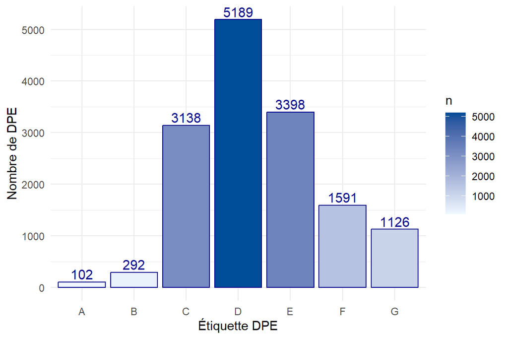

## % de répartition DPE

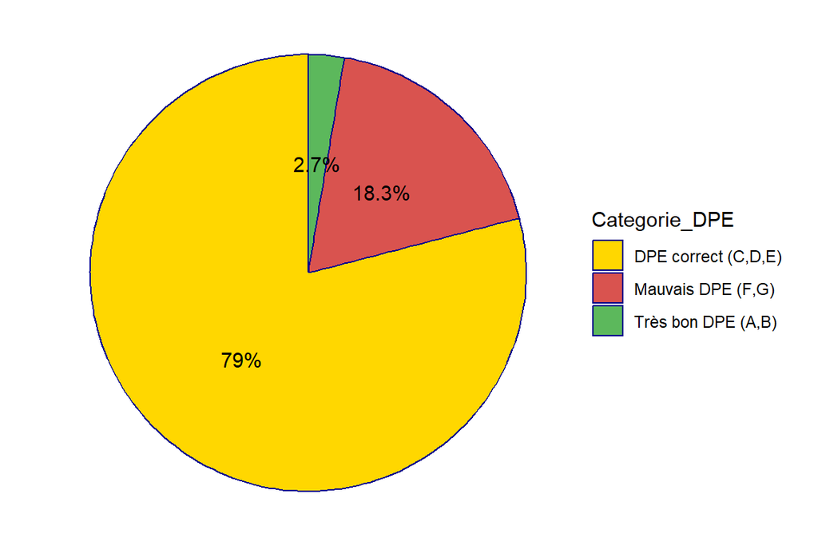

**Le graphique en camembert** ci-dessus représentant la répartition des DPE par catégorie dans le département de la **Meuse** nous offre une vision claire de la performance énergétique du parc immobilier. La situation énergétique du parc immobilier meusien est globalement satisfaisante, puisque 81.7 % des logements **ont un bon DPE** et 18.3 % en **ont un mauvais**. Il y a donc quand même des efforts de rénovation à accomplir pour améliorer la performance énergétique des 18.3 % logements les moins performants. Il est néanmoins intéressant de voir si les logements les moins performants sont des logements neufs ou anciens.

## Proportion des DPE par type de logement (ancien vs neuf)

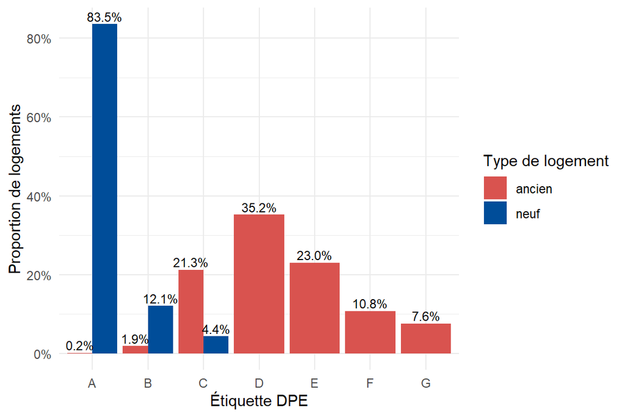

Grâce au **diagramme en barres groupées** ci-dessus, on peut affirmer que

**les logements neufs** sont bien *clairement plus performants* en termes d’efficacité énergétique, avec une **large majorité** ayant des DPE de classe **A**. En revanche, **les logements anciens** sont majoritairement dans les classes **D** et **E**, avec une proportion non négligeable dans les classes **F** et **G**, soulignant la *nécessité d’améliorations énergétiques* pour ces logements.

## Proportion des bons et mauvais DPE par type de logement

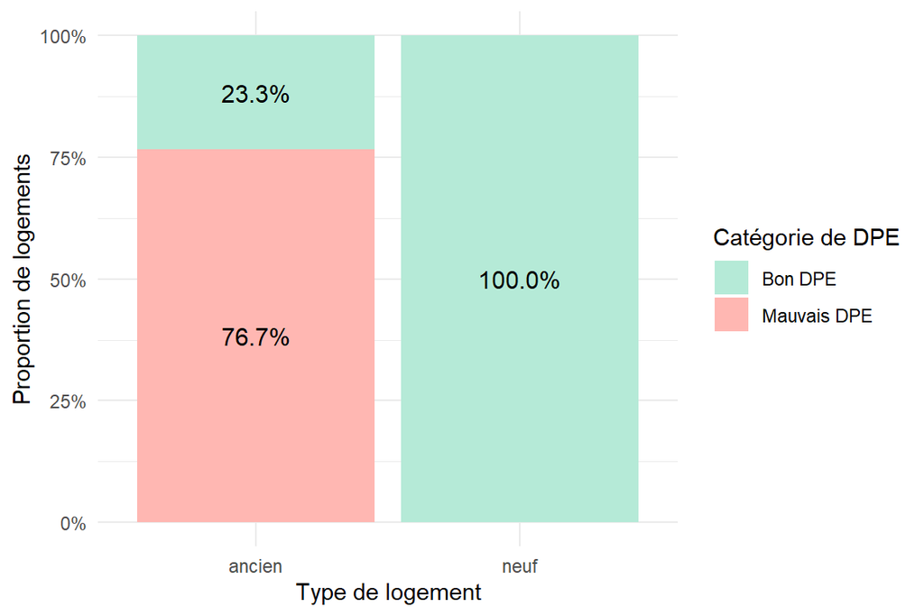

**Le diagramme en barres empilées** ci-dessus permet également de visualiser la proportion de **“bons” et “mauvais” DPE** par type de logement. On voit bien que **100% des logements neufs** ont un bon DPE (de **A à C**) tandis que seulement **23% des logements anciens** le sont.  
Il permet donc de **renforcer l’idée** que les **logements neufs sont nettement plus performants énergétiquement** que les logements anciens, et montre un **besoin important de rénovation énergétique** pour les logements anciens.

# Conclusion

**L’analyse des diagnostics de performance énergétique (DPE)** dans le département de la Meuse révèle des tendances significatives entre les **logements anciens** et **neufs**. Les **logements neufs** se distinguent par une **efficacité énergétique supérieure**, avec une majorité classée dans les catégories **A et B**, ce qui reflète les efforts récents en matière de **construction écologique** et d’**économie d’énergie**. En revanche, les **logements anciens** sont majoritairement classés dans les catégories intermédiaires **D et E**, ce qui souligne l’importance d’**entreprendre des rénovations énergétiques** pour améliorer leur performance.

L’étude a permis d’identifier une **corrélation** entre l’**âge des bâtiments** et leur **performance énergétique**, ce qui constitue une base solide pour des **politiques publiques** ciblées visant à réduire l’**empreinte carbone** du parc immobilier existant.

Les **visualisations présentées**, comme le **graphique de répartition des DPE** par type de logement et le **diagramme circulaire** sur les catégories de logements, ont illustré clairement ces différences et ont mis en évidence les points clés de l’analyse.

Cette petite étude montre donc l’importance de **cibler les logements anciens** pour atteindre les **objectifs de réduction de la consommation énergétique** et des **émissions de CO₂**, tout en valorisant les efforts déjà réalisés dans la construction de **nouveaux logements plus performants**.